# A multi-country Bayesian macro model

Structure, results and forecasts across eight estimated systems

## What this is

A **multi-country Bayesian simultaneous-equations macro model**, built on the `koma` package.

**The one thing that governs all of it:** every system spends observations on parameters. `df = T − k`. Nearly every result in this deck is downstream of that number.

## The country template — behavioural equations

Six equations per country, identical in form for every economy:

```
cc_consumption ~ cc_gdp + cc_long_rate + cc_consumption.L(1)
cc_investment ~ cc_gdp + cc_long_rate + cc_investment.L(1)
cc_exports ~ cc_foreign_demand + cc_exports.L(1)
cc_imports ~ cc_domestic_demand + cc_imports.L(1)
cc_prices ~ eur_usd + oil_price + cc_gdp + cc_prices.L(1)
cc_spread ~ cc_prices + cc_gdp + cc_spread.L(1)
```

- Estimated in **growth-rate space** — coefficients on volumes are elasticities
- `long_rate`, `spread` and the policy rates are **rates**: koma leaves them untransformed, so their coefficients are pp per pp
- Four COVID impulse dummies (2020Q1–Q3, 2021Q2) enter the five real-side equations; suppressed above for readability

## The country template — identities

Enforced **during** estimation, not fitted. Weights are fixed shares:

```
cc_gdp == 0.932*cc_domestic_demand + 0.406*cc_exports - 0.348*cc_imports
cc_domestic_demand == 0.731*cc_consumption + 0.269*cc_investment
cc_foreign_demand == 0.065*fr_imports + 0.052*it_imports + 0.098*us_imports + 0.104*cn_imports + 0.225*reu_imports + 0.456*row_gdp
cc_long_rate == 1*cc_spread + 1*ea_policy_rate
```

- **GDP** — expenditure decomposition, exact only up to the statistical discrepancy
- **Domestic demand** — absorption; government is out of the system entirely
- **Foreign demand** — the trade-weighted external demand index exports load on. **This is what links the countries.** The weights shown are Germany’s; the partner set and shares are country-specific by construction
- **Long rate** — a sovereign yield *is* the policy path plus a premium; both weights imposed at exactly 1

## Plus, once per system

```
ea_policy_rate ~ ea_prices + ea_gdp + ea_policy_rate.L(1)
us_policy_rate ~ us_prices + us_gdp + us_policy_rate.L(1)   (stage 2b onward)
cn_policy_rate ~ cn_prices + cn_gdp + cn_policy_rate.L(1)   (stage 2d only)

ea_gdp    == sum_i g_i * <member i>_gdp
ea_prices == sum_i g_i * <member i>_prices
```

There is exactly **one** `ea_policy_rate` equation however many euro-area countries the system contains — that is what makes it a genuinely common instrument rather than ten separate ones.

## The stages at a glance

| Stage | Scope | Eqs | k | T | df | Window |
| --- | --- | --- | --- | --- | --- | --- |
| Stage 1 | 11 countries, estimated separately (k, T, df are per country) | 6 + 2 | 12 | 78 | 66 | 2000Q1–2019Q4 |
| Stage 2a | DE + FR, one joint system | 13 + 8 | 19 | 78 | 59 | 2000Q1–2019Q4 |
| Stage 2b | 11 countries, one joint system | 68 + 35 | 76 | 98 | 22 | 2000Q1–2024Q4 |
| Stage 2c | 11 countries, four refinements | 68 + 46 | 76 | 98 | 22 | 2000Q1–2024Q4 |
| Stage 2d | 6 entities: DE FR IT US CN + REU bloc | 38 + 25 | 46 | 78 | 32 | 2005Q1–2024Q4 |
| Stage 3a | Stage 2b + German labour/price block | 74 + 39 | 83 | 98 | 15 | 2000Q1–2024Q4 |
| Stage 3b | Stage 3a + external/fiscal/financial | 79 + 43 | 90 | 98 | 8 | 2000Q1–2024Q4 |
| Stage 3d | Stage 2d + labour block on DE and the REU bloc | 50 + 33 | 60 | 78 | 18 | 2005Q1–2024Q4 |

Stage 1’s `k`/`T`/`df` are **per country** — its eleven satellites never share a design matrix. Everything from 2a on is one joint system.

## Stages 1 and 2a — the mechanism

**Stage 1** — each country its own small system, world variables exogenous.

**Stage 2a** — DE + FR in *one* system. Three things change, and they are the whole point:

- exports driven by **partner GDP**, not an exogenous world aggregate
- `ea_policy_rate` becomes **endogenous**
- `long_rate` enters **investment**

**The finding that set the agenda:**

Making the policy rate endogenous did **not** give it a route to output. Without `long_rate` in investment it reached only the two long-rate equations — which are terminal.

> “A rate rise cannot move GDP.”

Structure has to be *traced*, not assumed.

## Stage 2b — all eleven, and an open loop

68 stochastic equations, 35 identities, `k = 76`, `df = 22`.

Tracing what `ea_policy_rate` can reach within a quarter:

**91 of 103** endogenous variables — including every country’s GDP, and itself.

**0 of 11** price variables.

The Taylor rule responds to an inflation rate that **nothing it does can influence**. The monetary block was an open loop, and no amount of estimation would have revealed it — only a structural trace did.

## Stage 2c — closing the loop, for free

Four refinements, applied to every country. **All four cost zero `k`** — same `k = 76`, same `df = 22` as stage 2b, so the two are directly comparable.

| # | Refinement | Why |
| --- | --- | --- |
| 1 | `prices` gains `gdp` | the Phillips curve — closes the monetary loop |
| 2 | `foreign_demand` over partner **imports** | partner GDP nets imports out, so it had the wrong sign |
| 3 | model the **spread**, `long_rate` becomes an identity | policy-rate loading straddled zero in all 11 |
| 4 | `consumption` gains `long_rate` | a second monetary channel |

**Result:** the policy rate now reaches **all 114** endogenous variables, including every price. A fifth refinement was estimated and **rejected** — it halved in-sample RMSE while gutting the demand elasticity in 9 of 11 countries. *Improved fit was the symptom, not the reassurance.*

## Stage 2c — and what closing the loop cost

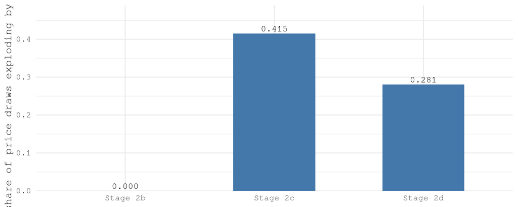

In stage 2b `prices` had **no** contemporaneous endogenous regressor — it was effectively a univariate AR, and therefore **structurally immune** to explosive draws. Coupling it to GDP makes it reachable from the policy rate *and* from everything else that reaches GDP.

**Use stage 2c for mechanism, stage 2b for a price fan chart.**

## Stage 2d — the first stage that *buys* degrees of freedom

Stage 2c’s equations, a **re-partitioned world**: `DE`, `FR`, `IT`, `US` separate, the other seven euro-area economies collapsed into a **`REU` bloc**, and **China** added.

| Stage | Change | k | df |
| --- | --- | --- | --- |
| Stage 2c | 11 countries, refined | 76 | 22 |
| Stage 3a | + German labour block | 83 | 15 |
| Stage 3b | + external/fiscal/financial | 90 | 8 |
| **Stage 2d** | **re-partition to 6 entities** | 46 | 32 |

## Stage 2d — China, and what the data does not have

**What exists** (free, keyless sources):

- real GDP, SA — World Bank GEM
- CPI — World Bank GEM
- merchandise trade volumes — GEM value ÷ price
- policy rate — OECD `IRSTCI`
- trade weights — **observed IMF DOTS**

**What does not exist, anywhere:**

**Quarterly consumption and investment.**

Verified absent from OECD QNA, OECD Economic Outlook, IMF IFS, World Bank GEM, FRED and the NBS itself.

→ the two equations **merge** into one estimated `cn_domestic_demand`, rather than being invented from indicator proxies.

Two things stated rather than buried: `cn_long_rate` is **spliced over 45%** of the window, and `reu_investment` is **not identified** — Ireland’s investment sd is 43.0 and it carries 10.9% of the bloc, so the seven-country average is *more* volatile than any single member.

## Stage 3a / 3b — the wall

Germany gets a labour/wage–price block, then external, fiscal and financial blocks on top.

| Stage | Adds | k | df |
| --- | --- | --- | --- |
| Stage 2b | — | 76 | 22 |
| Stage 3a | labour + disaggregated prices (DE only) | 83 | 15 |
| Stage 3b | + external, fiscal, financial (DE only) | 90 | 8 |

- **It cannot be rolled out** — on eleven countries. The full block for all of them needs `k = 142` against `T = 98`.
- At `df = 8`, `de_long_rate`’s own lag crossed to **1.004** — explosive — the moment debt became its fifth regressor.
- A quiet loop is not a stable one: the fiscal–financial cycle showed no explosive draws *because one of its links was ~0*.

## Stage 3d — the rollout, on the regional core

Stage 3c’s verdict was that further structure needed **a longer sample or a smaller system**. Stage 2d built the smaller system; stage 3d puts the labour block on it.

| Configuration | Partition | k | df | Economies covered |
| --- | --- | --- | --- | --- |
| DE labour only | 11 countries | 83 | 15 | 1 |
| DE + FR labour | 11 countries | 90 | 8 | 2 |
| **DE + REU labour** | **6 entities** | 60 | 18 | 8 |
| DE + REU + FR + IT | 6 entities | 74 | 4 | 10 |

**The block still costs seven columns per entity.** What changed is what a column buys: a bloc covers **seven economies for one entity’s worth of `k`**.

And the aggregation is not only a cost. The **wage Phillips curve is identified on the bloc** (−0.176, interval excluding zero) and not on Germany (−0.105, straddling zero) — the bloc’s unemployment rate carries the crisis-era variation Germany’s does not. What is lost is the *institutional* coefficients: wage indexation and ULC pass-through both go wrong-signed on the bloc. The bloc has the variation but not the institutions; Germany the reverse.

## Forecasts — how they are produced

Every system is run **8 quarters** forward, 1000 posterior draws.

- koma **silently shortens** a horizon whose exogenous series run out — they are extended first, and the delivered horizon is checked
- koma constrains no draw to be stationary, so **explosive draws are filtered** and the discarded share is reported
- Charts show an **inner 25–75%** band solid and an outer 10–90% band clipped to the panel edge; the untruncated bounds are tabulated
- Stages 1 and 2a forecast from **2023Q1** (window already observed — a genuine out-of-sample check); stages 2b onward from **2025Q1**

## Forecast — stage 2d GDP

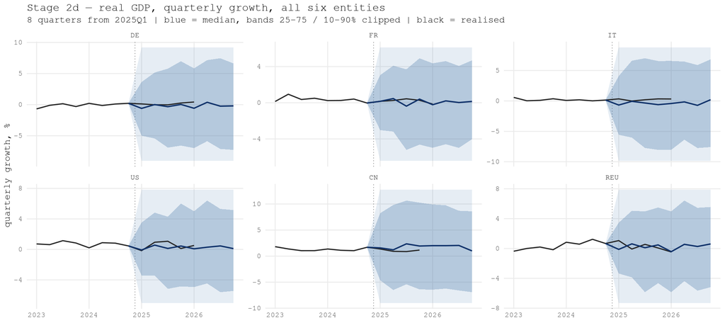

## Forecast — stage 1, against the outturn

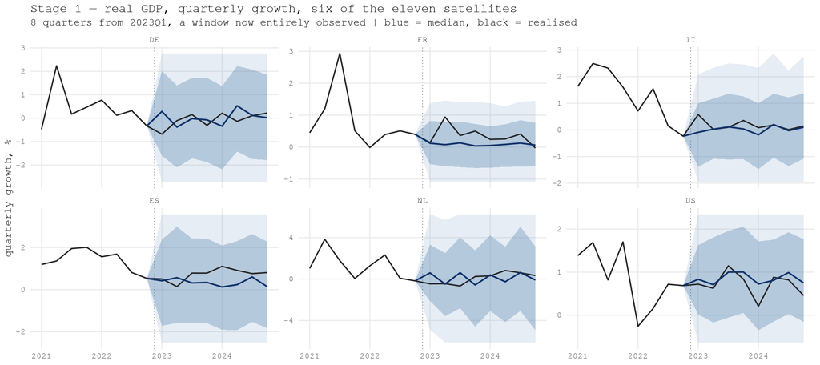

The realised path sits inside the band for every country, and the fan widens in exactly the countries you would expect.

## Forecast — German GDP, every stage side by side

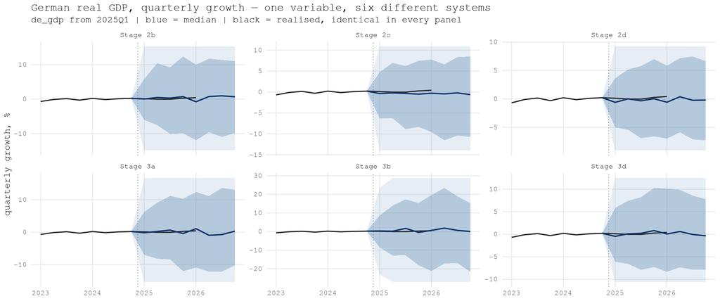

The **medians barely differ** – -0.63 to 0.67pp at horizon 8, a spread of 1.3pp. What differs is the **width of the band**: 51 to 103pp across the same six systems, and it tracks `df` at a rank correlation of **-0.90**. The systems disagree far less about where growth is going than about how much they know.

## Forecast — German prices, every stage side by side

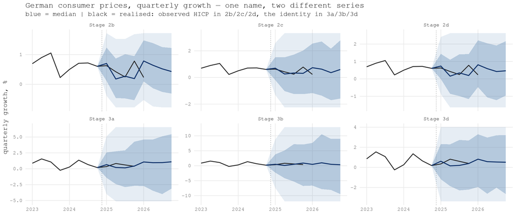

**The realised line is not the same in all six panels, and that is not a plotting error**

`de_prices` is **two different series** across these systems. In stages 2b, 2c and 2d it is observed headline HICP. Under the labour block — stages 3a, 3b and 3d — it becomes an *identity* over the energy and non-energy sub-indices, built with `chain_weighted_index()` rather than taken from observed HICP, because observed HICP satisfies a fixed-weight identity only approximately and koma has no identity-consistency check that would catch the difference. The two disagree by up to **0.65pp of quarterly growth**, and stage 3d differs again slightly from 3a/3b because its HICP weights are averaged over a different window (0.887/0.113 against 0.891/0.109).

So the top row and the bottom row are forecasting different definitions of German inflation, and only the fans *within* a row are strictly comparable. `common_forecast_variables()` detects exactly this and is why `de_prices` is excluded from the forecast-error scoreboard below.

| Stage | Explosive share of draws, h1 | h8 |
| --- | --- | --- |
| Stage 2b | 0.000 | 0.000 |
| Stage 2c | 0.001 | 0.409 |
| Stage 2d | 0.004 | 0.292 |
| Stage 3a | 0.009 | 0.524 |
| Stage 3b | 0.020 | 0.666 |
| Stage 3d | 0.009 | 0.446 |

## Forecast — stage 2d, prices across all six entities

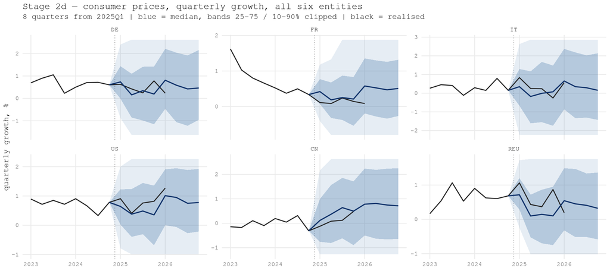

## Forecast errors — the stages against the outturn

Same 23 series, same origin, and — now checked rather than assumed — the same outturn:

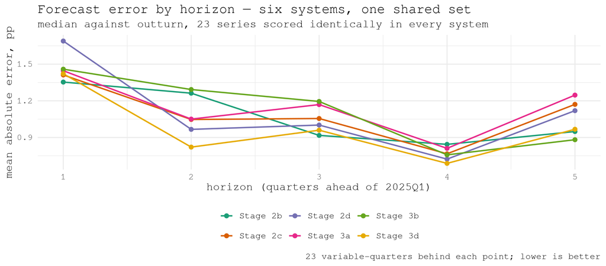

## Forecast errors — the numbers

| Stage | h1 | h2 | h3 | h4 | h5 | Mean |
| --- | --- | --- | --- | --- | --- | --- |
| Stage 2b | 1.35 | 1.26 | 0.92 | 0.84 | 0.95 | 1.06 |
| Stage 2c | 1.41 | 1.05 | 1.06 | 0.77 | 1.17 | 1.09 |
| Stage 2d | 1.69 | 0.97 | 1.00 | 0.72 | 1.12 | 1.10 |
| Stage 3a | 1.45 | 1.05 | 1.17 | 0.81 | 1.25 | 1.14 |
| Stage 3b | 1.46 | 1.29 | 1.19 | 0.76 | 0.88 | 1.12 |
| Stage 3d | 1.42 | 0.82 | 0.96 | 0.69 | 0.97 | 0.97 |

The spread across stages is **small relative to the level of the error** – every system is between 0.69 and 1.69pp at every horizon, and the ordering changes from one horizon to the next. Averaged over the five horizons **Stage 3d** is lowest at 0.97 and **Stage 3a** highest at 1.14, a gap of 18%. On five quarters and a single origin that ordering is a sanity check, not a ranking.

## Forecast errors — what one origin cannot settle

**Twenty origins, re-estimated at each one** — the comparison that can carry weight:

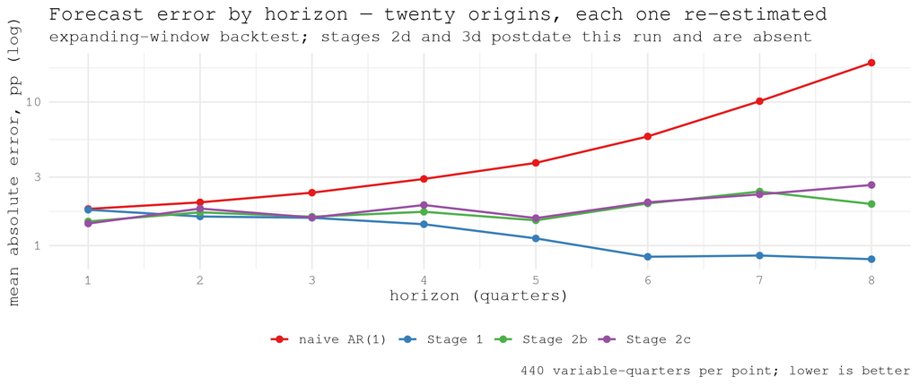

## Forecast errors — stages 1 and 2a, on their own origin

| Stage | h1 | h2 | h3 | h4 | h5 | h6 | h7 | h8 |
| --- | --- | --- | --- | --- | --- | --- | --- | --- |
| Stage 1 | 1.11 | 1.18 | 0.46 | 0.67 | 0.60 | 0.62 | 0.50 | 0.61 |
| Stage 2a | 1.15 | 1.12 | 0.51 | 0.79 | 0.59 | 0.57 | 0.57 | 0.62 |

Adding the linkage mechanism (2a) neither helped nor hurt the point forecast at this origin — which is what stage 2a was for. It was a test that the *mechanism* worked, not a bid for accuracy.

## The finding the forecasts made visible

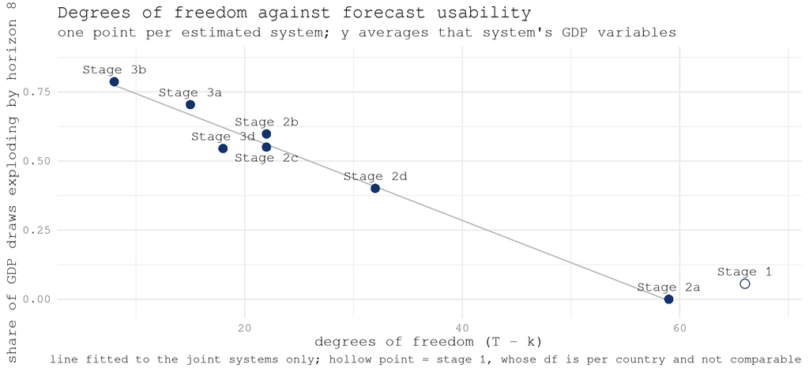

## Spillovers — stage 2d

Cumulative 8-quarter GDP effect of a **+1pp demand shock**; rows shocked, columns responding.

|  | de | fr | it | us | cn | reu |
| --- | --- | --- | --- | --- | --- | --- |
| de | 1.373 | 0.385 | 0.696 | 0.265 | 0.274 | 0.376 |
| fr | 1.123 | 1.387 | 1.162 | 0.443 | 0.442 | 0.837 |
| it | 0.664 | 0.400 | 1.208 | 0.265 | 0.332 | 0.486 |
| us | 0.834 | 0.454 | 0.605 | 1.155 | 0.220 | 0.703 |
| cn | 0.158 | 0.062 | 0.090 | 0.056 | 1.119 | 0.105 |
| reu | 0.827 | 0.608 | 0.964 | 0.495 | 0.479 | 1.398 |

Own effect dominates **6 of 6**. China’s row is an order of magnitude smaller than Europe’s — as its trade weights say it should be, now that they come from observed DOTS rather than the reciprocal approximation that would have put 56% of Chinese trade inside the euro area.

## Spillovers — is any of it real?

Same fit, same battery, **only the seed changed**:

| System | Mean \|A − B\| | Max | Sign flips |
| --- | --- | --- | --- |
| Stage 2b (df 22) | 0.350 | 1.850 | 7–10 of 30 |
| Stage 2c (df 22) | 0.119 | 0.356 | 1 of 44 |
| **Stage 2d (df 32)** | **0.108** | **0.273** | **0 of 20** |

For stage 2b, **most of what anyone wanted to conclude was smaller than the matrix’s own noise.**

Stage 2d is the first system where no off-diagonal cell changes sign when only the seed changes — the concrete payoff of those ten extra degrees of freedom.

## What does not work

| Check | Result |
| --- | --- |
| Monetary → GDP (euro area) | correctly signed, 6/6 peak negative |
| Monetary → prices | **wrong sign** — only 1/6 peak negative |
| Monetary shock on China’s own rule | **does not work** — a horizon-1 adjustment in the rule, not transmission |
| Oil → prices | correctly signed **6/6** |
| Spillover ~ bilateral trade weight | **fails** — Spearman 0.138 against a 0.3 bar |

The oil shock is the control: the price block responds sensibly to a **cost** shock and perversely to a **policy rate**. That localises the fault to the policy rate’s route in — not to the price equations.

## Which system for which question

| If you want to… | Use |
| --- | --- |
| understand a mechanism / trace transmission | **Stage 2c** |
| produce a price fan chart | **Stage 2b** |
| study EA–US–China spillovers | **Stage 2d** |
| say anything about Austria, Spain, Ireland… | Stage 2b / 2c |
| model German wages, debt or credit | Stage 3a / 3b — Germany only |
| run a monetary experiment on China | **nothing here yet** |

**The through-line:** every result in this deck that survived did so because it was checked against its own noise floor — a seed placebo, a sign rule, a structural trace, a second specification. The ones that did not survive are in the deck too.

## Reference

| Report | What it covers |
| --- | --- |
| `stage1_diagnostics.qmd` | per-country satellites, diagnostics |
| `stage2a_pilot.qmd` / `stage2b_full_system.qmd` | the linkage mechanism, then all eleven |
| `stage2c_refined_core.qmd` / `stage2c_equations.qmd` | the four refinements, every equation |
| `stage2d_regional_core.qmd` / `stage2d_equations.qmd` | the re-partition and China |
| `stage2d_spillovers.qmd` | shock battery + seed placebo |
| `stage3a_labour_prices.qmd` / `stage3b_*.qmd` | the extension blocks |
| `stage3c_rollout.qmd` / `stage3d_regional_blocks.qmd` | why the rollout stalled, and the partition that unstalled it |
| `evaluation.qmd` | expanding-window backtest, four specifications |

Artefacts: `scratch/overview_build.R`, `scratch/forecasts_build.R`, `scratch/stage2d_build.R`, `scratch/stage2d_spillovers_build.R`, `scratch/stage3d_build.R`.